# 资产定价模型(CAPM)港股实证研究

Yunlong(@algorithmx)

# [回主页](https://algorithmx.github.io)

```r
knitr::opts_chunk$set(echo = TRUE)
library(ggplot2)
library(Quandl)
library(fBasics)
library(timeSeries)
library(tidyr)
library(lubridate)
library(dplyr)
library(goft)
library(readxl)
library(comprehenr)
library(stringr)
library(fitdistrplus)
```

这篇笔记主要讨论港交所列出的当前可交易股票，是一系列探讨资产定价模型CAPM文章的第二篇。这是一篇严肃的笔记，部分内容曾作为相关课程作业。

# 数据

这篇笔记使用[stooq.com](https://stooq.com/db/h/)数据。如果你想运行程序，需要先从[这个链接](https://stooq.com/db/h/)下载所有港交所数据，并解压到这个笔记本所在的目录。之后我们将用路径`'./hk/hkex_stocks'`来访问股票数据文件。（我把子文件夹名字空格改成了下划线）

[上一篇笔记](https://algorithmx.github.io/capm/hkstooq1/)介绍了港股价格历史数据的基本情况，特别是一些股价历史数据奇异的股票。我们需要把平均交易量排名末5%，平均价格排名末5%，最高价格排名末5%的股票剔除，因为大多数portfolio不会考虑这样的股票。

```r
# 加载stooq文件
load_hk_stooq <- function(fn){
  df <- read.csv(fn)
  df <- data.frame(
    date=as.Date(as.character(df$X.DATE.),format=("%Y%m%d")),
    close=as.numeric(df$X.CLOSE.),
    volume=as.numeric(df$X.VOL.))
  return(df)
}
all_files <- list.files(path="./hk/hkex_stocks/")
stocks_all <- list()
for (f in all_files){
  df <- load_hk_stooq(paste0("./hk/hkex_stocks/",f))
  stocks_all <- append(stocks_all, list(df))
}
all_symbols <- to_vec(
  for (f in all_files)
    str_pad(str_replace(str_replace(f,".txt",""),".hk",".HK"),8,pad="0"))
# 排除平均交易量末5%，平均价格末5%，最高价格末5%，上市日期晚于2021-07-01
mean_price     <- to_vec(for (df in stocks_all) mean(df$close))  %>% as.numeric
mean_volume    <- to_vec(for (df in stocks_all) mean(df$volume)) %>% as.numeric
max_price      <- to_vec(for (df in stocks_all) max(df$close))   %>% as.numeric
earliest_date  <- to_vec(for (df in stocks_all) min(df$date))    %>% as.Date
h_95pct_mean_p <- (mean_price  > quantile(mean_price,  probs=c(0.05), na.rm=TRUE))
h_95pct_mean_v <- (mean_volume > quantile(mean_volume, probs=c(0.05), na.rm=TRUE))
h_95pct_max_p  <- (max_price   > quantile(max_price,   probs=c(0.05), na.rm=TRUE))
date_lt_07_01  <- (earliest_date < as.Date("2021-07-01"))
# 剩下的id
selected_id    <- which(((h_95pct_mean_p & h_95pct_mean_v) & h_95pct_max_p) & date_lt_07_01)
```

下面的代码将日线交易信息转化成月线交易信息。转化是按照日历日期进行的，并未按照交易日历。

```r
# 日期限定
start_date <- as.Date("2006-02-01")
end_date   <- as.Date("2021-12-31")
# 转化成月度数据
convert_to_monthly <- function(df){
  # add column "month"
  df1 <- data.frame(
    date=as.Date(df$date),
    close=as.numeric(df$close),
    month=floor_date(df$date,"month"))
  if ("volume" %in% colnames(df)){
    df1$volume = as.numeric(df$volume)
    # monthly average/min/max price and total volume
    df2 <- df1 %>%
      group_by(month) %>%
      summarize(close.avg=mean(close,na.rm=TRUE),
                close.var=var(close,na.rm=TRUE),
                close.min=min(close,na.rm=TRUE),
                close.max=max(close,na.rm=TRUE),
                volume=sum(volume,na.rm=TRUE)) %>%
      as.data.frame
  }
  else{
    # monthly average/min/max price and total volume
    df2 <- df1 %>%
      group_by(month) %>%
      summarize(close.avg=mean(close,na.rm=TRUE),
                close.var=var(close,na.rm=TRUE),
                close.min=min(close,na.rm=TRUE),
                close.max=max(close,na.rm=TRUE)) %>%
      as.data.frame
  }
  # select date within range
  df3 <- df2[start_date<=df2$month & end_date>=df2$month,]
  # fill missing data
  if (nrow(df3)==0){
    # end date is earlier than the date of list
    return(df3)
  }
  else{
    # enforce consecutive monthly data
    conseq_date <- data.frame(
      month=seq.Date(min(df3$month), max(df3$month), by="month"))
    # fill the missing data
    if ("volume" %in% colnames(df)){
      df4 <- merge(conseq_date, df3, by="month", all.x = TRUE) %>%
        fill(c(close.avg,close.var,close.min,close.max,volume))
    }
    else{
      df4 <- merge(conseq_date, df3, by="month", all.x = TRUE) %>%
        fill(c(close.avg,close.var,close.min,close.max))
    }
    return(df4)
  }
}
stocks_all_monthly <- list()
for (i in 1:length(stocks_all)){
  df <- convert_to_monthly(stocks_all[[i]])
  stocks_all_monthly <- append(stocks_all_monthly, list(df))
}
```

为了今后方便，我们把转化后的数据存到几张表格里。

```r
# 191 months
dates00 <- data.frame(month=seq.Date(start_date, end_date, by="month"))
# fill NA to monthly data before the date of listing
fill_na <- function(st,x){
  df <- merge(dates00, st[,c("month",x)], by="month", all.x = TRUE) %>%
              fill(c(x))
  return(df[,c(x)])
}
# save field x to file 'all_stocks_<x>.csv'
save_x <- function(x){
  M <- matrix(nrow=length(stocks_all_monthly),ncol=nrow(dates00))
  for (i in 1:length(stocks_all_monthly)){
    M[i,] <- fill_na(stocks_all_monthly[[i]],x)
  }
  dfall <- as.data.frame(M)
  names(dfall) <- dates00$month
  dfall$symbols <- all_symbols
  write.csv(dfall,paste0(paste0("all_stocks_",x),".csv"))
  return()
}
```

```r
save_x("close.avg")
```

```r
save_x("close.var")
```

```r
save_x("volume")
```

# 资产定价模型(CAPM)

## 模型

$$[R_{i,t}-R_{f,t}]=\beta_{i}[R_{M,t}-R_{f,t}]+e_{i,t},
\; t=0,1,2,...,T, \; i=1,2,...,N,$$
其中$R_i-R_f$是资产$i$的超额回报，即该资产的回报$R_i$与无风险回报$R_f$之差； 市场超额回报$R_M-R_f$是全市场回报$R_M$与无风险回报$R_f$之差。 无风险回报$R_f$取决于投资者，对于个人通常可以认为是银行存款利率， 对于机构则是银行间拆借利率。通常后者比前者低得多。 系数$\beta_i$通常为正数，它反映资产$i$相对于市场获得超额收益的能力。 $e_{i,t}$是正态分布的随机同分布变量，它与市场回报无关联：

$$cov(R_M,e_i) = 0.$$

这些$e_{i,t}$的统计学性质是CAPM的核心内容，需要在市场数据上进行统计检验。

## 对数回报

对数回报$r_t$定义为：

$$r_t \equiv {\rm log}(P_t/P_{t-1}) = {\rm
diff}({\rm log}(P))_t$$

```r
# 计算对数回报
difflog <- function(x){return(diff(log(x)))}
```

我们采用月度时间序列计算$R_i$、$R_M$和$R_f$。

## 无风险回报率

我们采用季度 [Hong Kong dollar interest settlement rate](https://www.censtatd.gov.hk/en/web_table.html?id=123) 作为无风险回报率。严格说这只是一个上限。 [可以从此处下载](https://algorithmx.github.io/capm/ISR.csv)

```r
load_ISR <- function(fn){
  df <- read.csv(fn)
  df1 <- df[rep(seq_len(nrow(df)), each = 3), ]
  df2 <- data.frame(
    close=as.numeric(df1$X1.month)[2:length(df1$X1.month)],
    month=seq(as.Date("2006/2/1"), by = "month", length.out = length(df1$Year)-1))
  return(df2[start_date<=df2$month & end_date>=df2$month,])
}
ISR_monthly <- load_ISR("./hk/ISR.csv")
```

## 市场回报率

我们采用 [恒生指数](https://www.hsi.com.hk/) 作为市场回报率。 [可以从此处下载](https://algorithmx.github.io/capm/HSI.csv)

```r
load_HSI <- function(fn){
  df <- read.csv(fn)
  date <- as.Date(as.character(df$Date),format=("%m/%d/%y"))
  close <- as.numeric(df$Close)
  df1 <- data.frame(date=date, close=close)
  return(df1)
}
HSI_monthly <- convert_to_monthly(load_HSI("./hk/HSI.csv"))
```

## 一个例子：HK.00005（汇丰银行）

我们用一个例子来说明如何检验CAPM。首先我们把 HK.00005 历史股价和恒生指数、HKD interest settlement rate画在一起展示：

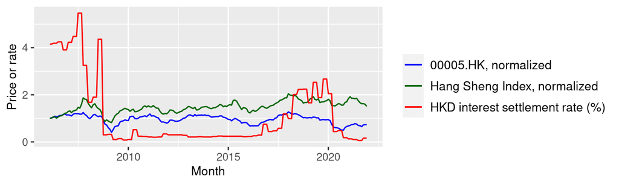

```r
df1 <- stocks_all_monthly[[which(all_symbols=="00005.HK")]]
p <-  ggplot() +
      geom_line(
          data=df1,
          aes(x=month,y=close.avg/close.avg[1],color='00005.HK, normalized')) +
      geom_line(
          data=HSI_monthly,
          aes(x=month,y=close.avg/close.avg[1],color='Hang Sheng Index, normalized')) +
      geom_line(
          data=ISR_monthly,
          aes(x=month,y=close,color='HKD interest settlement rate (%)')) +
      labs(x="Month", y="Price or rate") +
      scale_color_manual(name='',
                         breaks=c('00005.HK, normalized',
                                  'Hang Sheng Index, normalized',
                                  'HKD interest settlement rate (%)'),
                         values=c('00005.HK, normalized'='blue',
                                  'Hang Sheng Index, normalized'='darkgreen',
                                  'HKD interest settlement rate (%)'='red')) +
      theme(legend.title=element_text(size=10),
            legend.text=element_text(size=10),
            legend.position = "right",
            axis.title.x = element_text(size=10),
            axis.title.y = element_text(size=10))
p
```

我们进一步画出$A=[R_i-R_f]$和$X=[R_M-R_f]$的关系图，就会看到它们的线性关系非常明显：

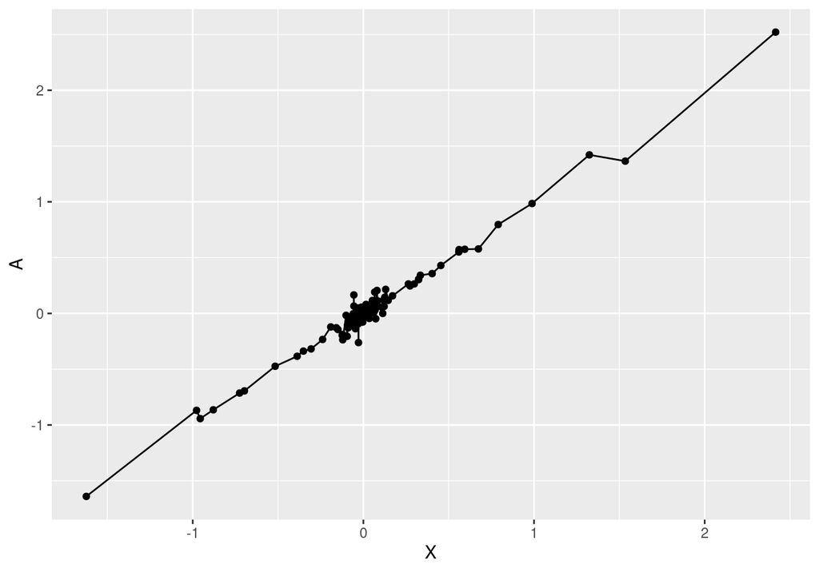

```r
R_i <- difflog(stocks_all_monthly[[which(all_symbols=="00005.HK")]]$close.avg)
R_f <- difflog(ISR_monthly$close)
R_M <- difflog(HSI_monthly$close.avg)
df <- data.frame(A = R_i - R_f, X = R_M - R_f)
p <-  ggplot() +
      geom_point(data=df,aes(x=X,y=A)) +
      geom_line(data=df,aes(x=X,y=A))
p
```

我们马上可以作一个线性拟合得到$\beta_i$：

```r
A = R_i - R_f
X = R_M - R_f
fit_hk00005 <- lm(A~X)
summary(fit_hk00005)
```

```
##
## Call:
## lm(formula = A ~ X)
##
## Residuals:
##       Min        1Q    Median        3Q       Max
## -0.229738 -0.025989 -0.001751  0.023463  0.224642
##
## Coefficients:
##              Estimate Std. Error t value Pr(>|t|)
## (Intercept) -0.003676   0.003655  -1.006    0.316
## X            0.991962   0.010885  91.133   <2e-16 ***
## ---
## Signif. codes:  0 '***' 0.001 '**' 0.01 '*' 0.05 '.' 0.1 ' ' 1
##
## Residual standard error: 0.0503 on 188 degrees of freedom
## Multiple R-squared:  0.9779, Adjusted R-squared:  0.9777
## F-statistic:  8305 on 1 and 188 DF,  p-value: < 2.2e-16
```

从拟合结果看到，$\beta_i=$ 0.9919616，结果显著；但截距是否为零，不能确定。[附录2]

再将余项$e_{i,t}$算出并画出分布：

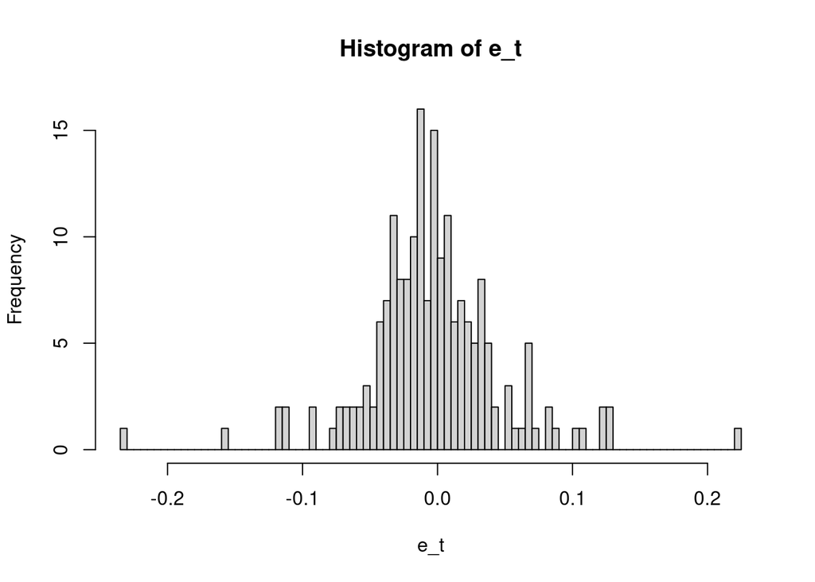

```r
e_t <- A - fit_hk00005$coefficients["X"]*X
hist(e_t,breaks=100)
```

很明显，这个分布不是正态分布。

```r
shapiro.test(e_t)
```

```
##
##  Shapiro-Wilk normality test
##
## data:  e_t
## W = 0.93358, p-value = 1.229e-07
```

**至此我们说：CAPM被00005.HK这支股票拒绝了！**

## 全部检验一遍！

我们把之前的过程运用到每一支股票上，统计一下结果。 如果每一支股票的历史价格都拒绝CAPM，那这算是重大发现呢:-)

首先我们来做一个函数，把上一节所有流程都放进去。

```r
# 对一支股票的历史价格数据，拟合CAPM
fit_CAPM <- function(asset_monthly){
  msk_R_i <- end_date>=asset_monthly$month & start_date<=asset_monthly$month
  msk_R_f <- ((min(asset_monthly$month)<=ISR_monthly$month & start_date<=ISR_monthly$month)
              & end_date>=ISR_monthly$month)
  msk_R_M <- ((min(asset_monthly$month)<=HSI_monthly$month & start_date<=HSI_monthly$month)
              & end_date>=HSI_monthly$month)
  R_f <- ISR_monthly[msk_R_f, "close"]
  R_f <- R_f[2:length(R_f)]
  R_M <- diff(log( HSI_monthly[msk_R_M, "close.avg"] ))
  R_i <- diff(log( asset_monthly[msk_R_i,"close.avg"] ))
  A <- R_i - R_f
  X <- R_M - R_f
  fit <- lm(A~X)
  return(fit)
}
```

还有几个方便后面使用的函数：

```r
# 调用方便
fit_CAPM_symbol <- function(sb){
  return(fit_CAPM(stocks_all_monthly[[which(all_symbols==sb)]]))
}
# 计算余项 e_t
calc_res <- function(ft){
  r <- ft$model$A - ft$coefficients["X"] * ft$model$X
  return(r)
}
```

然后把所有选定的股票都做一遍CAPM的拟合：

```r
stocks_selected_monthly <- stocks_all_monthly[selected_id]
symbol_selected <- all_symbols[selected_id]
fit_selected <- list()
for (st in stocks_selected_monthly){
  fit_selected <- append(fit_selected, list(fit_CAPM(st)))
}
```

最后统计结果：

```r
# regression result: coeff on X, or, beta
Xcoeff <- c()
# regression result: intercept, or alpha
Intcpt <- c()
vIntcpt <- c()
#
SMB <- c()
PVX <- c()
PVR <- c()
for (i in 1:length(fit_selected)){
  ft <- fit_selected[[i]]
  s <- summary(ft)
  r <- calc_res(ft)
  t <- shapiro.test(r)
  fd <- fitdistr(r,"normal")
  Xcoeff <- c(Xcoeff,  as.numeric(ft$coefficients["X"]))
  Intcpt <- c(Intcpt,  as.numeric(fd$estimate["mean"]))
  vIntcpt<- c(vIntcpt, as.numeric(fd$estimate["sd"]))
  SMB    <- c(SMB, symbol_selected[[i]])
  PVX    <- c(PVX, as.numeric(s$coefficients["X","Pr(>|t|)"]))
  PVR    <- c(PVR, as.numeric(t$p.value))
}
fit_results <- data.frame(
    symbol=SMB,
    X=Xcoeff,
    et.avg=Intcpt, et.sd=vIntcpt,
    pval.x=PVX, pval.t=PVR)
fit_results_accX <- fit_results[fit_results$pval.x<0.005,]
fit_results_accR <- fit_results[fit_results$pval.t>0.05,]
fit_results_acc  <- fit_results[fit_results$pval.t>0.05 & fit_results$pval.x<0.005,]
```

将结果保存下来：

```r
write.csv(fit_results,"CAPM_fit_results_on_selected_HK_stocks.csv")
```

如果你想直接从结果出发做一些自己感兴趣的观察，你可以下载并加载[这个文件](https://algorithmx.github.io/capm/CAPM_fit_results_on_selected_HK_stocks.csv)。文件里的列名字和上面代码中的一致，它们的意义如下： + X: the beta coefficient + et.avg : estimated mean of the normal distribution $e_{i,t}$, only valid when pval.t>0.05 + et.sd : estimated std of the normal distribution $e_{i,t}$, only valid when pval.t>0.05 + pval.x : p-value of the estimate of coefficient on X in the linear regression result, better to be less than 0.005 + pval.t : p-value of the Shapiro-Wilk normality test, has to be greater than 0.05

## 结果展示

对于支持CAPM的股票，$\beta$系数的拟合结果有如下分布：

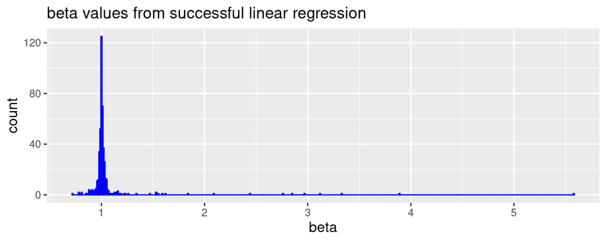

对于支持CAPM的股票，$\big<e_i\big>$的估计结果有如下分布：

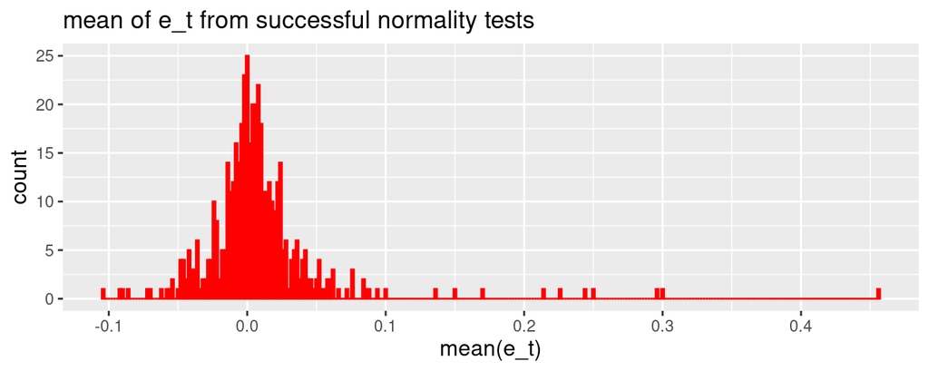

我们总共挑选了 1906 支股票进行CAPM检验， 结果有 469 支股票的月历史数据支持CAPM， 仅占四分之一。

**结果的分析请见下集～**

# 附录1：CAPM基本假设

参考书：CFA Curriculum 2018, Level I, Reading 42.

CAPM基本假设是：

- Investors are risk-averse, utility-maximizing, rational individuals
- Markets are frictionless, including no transaction costs and no taxes
- Investors plan for the same single hodling period.
- Investors have homogeneous expectations or beliefs.
- All investments are infinitely divisible.
- Investors are price takers.

# 附录2：00005.HK拟合结果的解释

正文中我们做了下面的线性拟合：

```r
fit_hk00005 <- lm(A~X)
summary.lm(fit_hk00005)
```

```
##
## Call:
## lm(formula = A ~ X)
##
## Residuals:
##       Min        1Q    Median        3Q       Max
## -0.229738 -0.025989 -0.001751  0.023463  0.224642
##
## Coefficients:
##              Estimate Std. Error t value Pr(>|t|)
## (Intercept) -0.003676   0.003655  -1.006    0.316
## X            0.991962   0.010885  91.133   <2e-16 ***
## ---
## Signif. codes:  0 '***' 0.001 '**' 0.01 '*' 0.05 '.' 0.1 ' ' 1
##
## Residual standard error: 0.0503 on 188 degrees of freedom
## Multiple R-squared:  0.9779, Adjusted R-squared:  0.9777
## F-statistic:  8305 on 1 and 188 DF,  p-value: < 2.2e-16
```

下面对此做详细解释。参考书：C. Dougherty, Introduction to Econometrics, 3rd Edition.

- Residuals 一栏，通过 quantiles 给出了余项(residuals)的大致分布
- 余项的定义是 ${\rm residuals} = Y_{data} - Y_{model}=Y_{data} - c X_{data} - x_0$，其中$c,x_0$是拟合结果
- Coefficients 一栏给出了截距 (Intercept) 和斜率 X 的拟合结果，包括估计值(estimate)，标准误(std. error)，t值(t value)，和Pr(>|t|)。
- 在`summary.lm`代码里，t值(t value)的定义是`tval=est/se`，其中`est`是拟合结果，`se`是经过一系列计算的标准误。这个值是要带入Student-t分布`pt(abs(tval), rdf, lower.tail = FALSE)`来计算p-value。
- Pr(>|t|)就是p-value，它的值是`pval = 2*pt(abs(tval), rdf, lower.tail = FALSE)`，其中`rdf`是residual degrees of freedom.

Based on the above information, we analyze the regression report as follows. We have degrees of freedom `fit_hk00005$df.residual` = 188. This corresponds to a Student-t distribution:

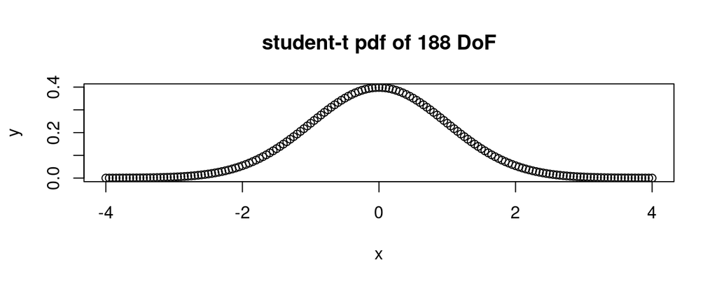

```r
x <- seq(from=-4,to=4,by=0.05)
y <- dt(x,fit_hk00005$df.residual)
plot(x,y)
title("student-t pdf of 188 DoF")
```

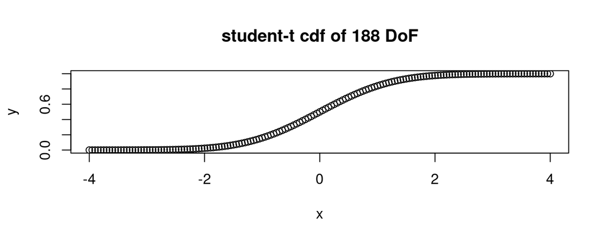

```r
x <- seq(from=-4,to=4,by=0.05)
y <- pt(x,fit_hk00005$df.residual)
plot(x,y)
title("student-t cdf of 188 DoF")
```

The reject/accept conclusion is based on the t-value. The proof of t-distribution can be found [here](https://stats.stackexchange.com/questions/286179/why-is-a-t-distribution-used-for-hypothesis-testing-a-linear-regression-coeffici), or in any standard textbook on statistics. First, we choose a confidence level, say 5%. It means that we restrict ourselves to the possibility less than 5% of making an Type-I mistake. Thus the confidence interval is [ -1.9726627 , 1.9726627 ]. The null hypothesis H0 is “the regression result vanishes.” We have a very large t-value for the coefficient on X to reject H0 at confidence level 95%. In fact, such a large t-value means that it is almost certain that H0 is false, or equivalently, “the coefficient on X does not vanish”. Both of the chances of type-I (reject a true hypothesis) and type-II (do not reject a false hypothesis) mistake are low. In contrast, the t-value for the intercept falls into the interval, dictating that we **do not reject** (or, accept?) H0. But this conclusion is less reliable and the chance of type-II mistake could be high. The failure of “rejecting the interception being zero by confidence level of 95%” does not imply an acceptance of “interception not being zero” at any confidence level. The situation is complicated.